# Improving MCMC

NIMBLE Development Team

2025-02-05

## Example Depletion Study

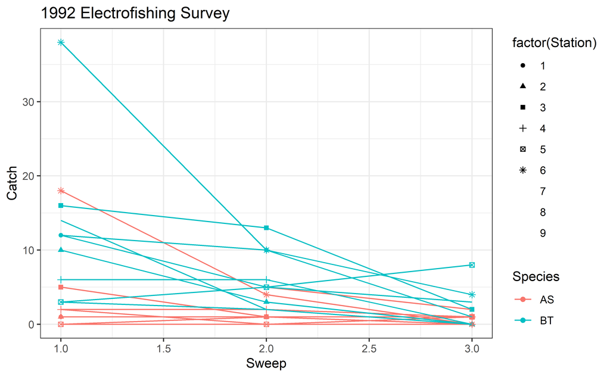

```r
library(tidyverse)
remdf <- read.csv("data/removal_data.csv")
catch <- remdf %>%
  pivot_wider(id_cols = c(Site, Station, Year, Sweep), names_from = Species,
              values_from = Fish.ID, values_fn = ~ length(.x), values_fill = 0) %>%
              pivot_longer(unique(remdf$Species), names_to = "Species", values_to = "Catch")

catch <- catch %>% group_by(Site, Station, Year, Species) %>%
  arrange(Sweep) %>%
  mutate(nCatch = cumsum(Catch)-Catch[1]) %>%
  ungroup() %>%
  mutate(Station = as.numeric(Station))

ggplot(data = catch %>% filter(Year == 1992, Species %in% c("AS", "BT")),
    aes(x = Sweep, y = Catch, colour = Species, shape = factor(Station))) +
  geom_point() +
  geom_line() +
  theme_bw() +
  ylab("Catch") + xlab("Sweep") +
  ggtitle("1992 Electrofishing Survey")
```

A basic model for fish depletion can be written as an unknown fish population $N$, being depleted $n$ times. We can assume that the population is Poisson distributed with a mean $\lambda$ that is gamma distributed. This is called a Poisson-Gamma mixture, and is exactly a negative binomial for a single station. We will assume that each station, $s$, is a random draw from the same mean ($\lambda$).

$$\begin{aligned}
N_s & \sim \mbox{Poisson}(\lambda)\\
\lambda & \sim \mbox{gamma}(0.1, 0.1)
\end{aligned}$$

Each catch ($C_i$), the number of remaining fish are caught with probability $p_i$, that depends on some covariates ($X$).

$$\begin{aligned}
C_i & \sim \mbox{Binomial}(N - \sum_{k<i} C_k, p_i)\\
\mbox{logit}(p_i) & = \sum \beta_k x_{ik}
\end{aligned}$$

For this particular example, we will assume that Atlantic salmon and Brook trout share some information about catchability at each site using a random effect and some basic species specific detectability.

```r
library(nimble)
model_code <- nimbleCode({

  b0[1] ~ dnorm(0, sd = 3)
  b0[2] ~ dnorm(0, sd = 3)
  sdre ~ dunif(0, 10)

  lambda[1] ~ dgamma(0.1,0.1)
  lambda[2] ~ dgamma(0.1,0.1)

  for( s in 1:nstation ){
    re[s] ~ dnorm(0, sd = sdre) # non-centered parameterization
    N[s,1] ~ dpois(lambda[1])
    N[s,2] ~ dpois(lambda[2])
  }

  for( i in 1:nobs ){
    logit(p[i]) <- b0[spp[i]] + re[station[i]]
    caught[i] ~ dbinom(size = N[station[i], spp[i]] - total[i], prob = p[i])
  }
})

dat92 <- catch %>% filter(Year == 1992, Species %in% c("AS", "BT"))
data <- list(caught = dat92$Catch)
constants <- list(nobs = nrow(dat92), total = dat92$nCatch,
                  nstation = length(unique(dat92$Station)),
                  station = dat92$Station, spp = as.numeric(factor(dat92$Species)))

maxn <- dat92 %>%
  group_by(Station, Species) %>%
  summarize(n = sum(Catch), .groups = "drop") %>%
  pivot_wider(names_from = Species, values_from = n)

inits <- function(){
  list(N = as.matrix(maxn[,c("AS", "BT")] + 10, ncol = 2),
       lambda = c(mean(maxn$AS+10), mean(maxn$BT+10)), b0 = rnorm(2,0,1),
       re = rnorm(constants$nstation, 0, 1), sdre = runif(1,0.5,2))
}
Rmodel <- nimbleModel(model_code, data = data, constants = constants, inits = inits())

conf <- configureMCMC(Rmodel, monitors = c("b0", "sdre", "lambda", "N", "p"))
Rmcmc <- buildMCMC(conf)
Cmodel <- compileNimble(Rmodel)
Cmcmc <- compileNimble(Rmcmc, project = Rmodel)
samples <- runMCMC(Cmcmc, niter = 10000, nburnin = 2000, nchains = 3, inits = inits(), samplesAsCodaMCMC = TRUE)
plot(samples[,'sdre'])
plot(samples[,'b0[1]'])
plot(samples[,'b0[2]'])
plot(samples[,'lambda[1]'])
plot(samples[,'lambda[2]'])
```

[output not shown]

Running 10,000 iterations for many analyses is not enough to be confident that we are fully sampling the posterior distribution. We have options to increase the number of samples, or to explore better samplers that explore posterior more effectively per iteration, although potentially at the cost of computation speed. Check out `help(samplers)` to help choose.

```r
sumdf <- data.frame(do.call("cbind", summary(samples)))
sumdf$parameter = gsub("\\[.*", "", rownames(sumdf))
sumdf$idx = gsub("*.\\[|\\]", "", rownames(sumdf))
sumdf$Station = factor(gsub(",.*", "", sumdf$idx))
sumdf$Species = c("AS", "BT")[as.numeric(gsub("*.,", "", sumdf$idx))]
sumdf <- sumdf %>%
  mutate(Species = ifelse(idx == "lambd1", "AS", Species)) %>%
  mutate(Species = ifelse(idx == "lambd2", "BT", Species))

ggplot(data = sumdf %>% filter(parameter == "N"), aes(x = Station, y = Mean, colour = Species)) +
  geom_point(position = position_dodge(width = 0.25)) +
  theme_bw() +
  geom_errorbar(aes(ymin = X2.5., ymax = X97.5., colour = Species),
    position = position_dodge(width = 0.25), width = 0.1) +
  geom_hline(data = sumdf %>% filter(parameter == "lambda"),
    aes(yintercept = Mean, colour= Species), linetype='dashed')

pout <- sumdf %>% filter(parameter == "p")
datp <- cbind(dat92, pout[, 1:10])
ggplot(data = datp, aes(x = Station, y = Mean, colour = Species)) +
  geom_point(position = position_dodge(width = 0.25)) +
  theme_bw() +
  geom_errorbar(aes(ymin = X2.5., ymax = X97.5., colour = Species),
    position = position_dodge(width = 0.25), width = 0.1)
```

[output not shown]

## Some strategies for improving MCMC

- Customize sampler choices. E.g.,
  - Try sampling standard deviations on a log scale
  - Try slice samplers instead of Metropolis-Hastings
  - Try blocking correlated parameters
  - Try multiple samplers for slow-mixing parameters [not shown].
- Reparameterize
  - Center covariates
  - Centered versus non-centered random effects parameterization
  - Rotated coordinates to reduce posterior correlation
- Rewrite the model. E.g.,
  - Rewrite the model to reduce dependencies
  - Vectorize declarations to improve computational efficiency
  - Marginalize to remove parameters
- (Advanced) Write new samplers that take advantage of particular model structures

We will start to look at which parameters are correlated and try blocking to improve mixing. Note that blocking is a good strategy to reduce computation time as well as improve mixing. Each iteration of the MCMC requires fewer computation steps when we sample in block. For instance in this example, when we sample `b0[1]` and `lambda[1]` separately, we change first change `b0[1]`, compute the density and the accept/reject, and then change `lambda[1]`, compute the density and accept/reject. By combining these into a block, we change them both at the same time, then compute the density and accept/reject.

*Discussion* Would we get a speed up if we block `b0[1]` and `b0[2]`?

```r
## Subset for key parameters
library(coda)
ids <- grepl("lambda|b0|sdre", colnames(samples[[1]]))
out <- as.mcmc.list(lapply(samples, FUN = function(x){as.mcmc(x[, ids])}))
crosscorr.plot(out)
```

[output not shown]

```r
conf$removeSamplers(c("b0", "lambda"))
conf$addSampler(c("b0[1]", "lambda[1]"), type = "RW_block")
conf$addSampler(c("lambda[2]", "b0[2]"), type = "RW_block")
Rmcmc <- buildMCMC(conf)
Cmodel <- compileNimble(Rmodel)
Cmcmc <- compileNimble(Rmcmc, project = Rmodel)
samples.rw <- runMCMC(Cmcmc, niter = 10000, nburnin = 2000, nchains = 3, inits = inits(), samplesAsCodaMCMC = TRUE)
plot(samples.rw[, "b0[1]"])
plot(samples.rw[, "lambda[1]"])
```

[output not shown]

*Discussion* What can we marginalize in this model?

## Sampler choices

- Sampling standard deviations on the log scale can help, especially when there is posterior support near 0.
- Slice sampling can help mix a parameter at some computational cost.
- Hamiltonian Monte Carlo (HMC) can help mix blocks of parameters (often all parameters at once) but at heavy computational cost.
- Blocking can help when parameters are correlated *given other parameters*.
  - If parameters are *marginally correlated* but *conditionally independent*, blocking will not help.
  - This occurs if parameters are marginally correlated only because they both depend on something else.
- Model-specific understanding can yield good sampling strategies.

Let’s try a slice sampler on these in a block. This will be slower but better mixing. We will also sample `sdre` on the log scale.

```r
conf$removeSamplers(c("b0", "lambda", "sdre"))
conf$addSampler(c("b0[1]", "lambda[1]"), type = "AF_slice")
conf$addSampler(c("b0[2]", "lambda[2]"), type = "AF_slice")
conf$addSampler("sdre", type = "RW", control = list(log = TRUE))
Rmcmc <- buildMCMC(conf)
Cmodel <- compileNimble(Rmodel)
Cmcmc <- compileNimble(Rmcmc, project = Rmodel)
samples.sl <- runMCMC(Cmcmc, niter = 10000, nburnin = 2000, nchains = 3, inits = inits(), samplesAsCodaMCMC = TRUE)
plot(samples.sl[, "b0[1]"])
plot(samples.sl[, "lambda[1]"])
plot(samples.sl[, "sdre"])

ids <- grepl("lambda|b0|sdre", colnames(samples[[1]]))
out <- as.mcmc.list(lapply(samples.sl, FUN = function(x){as.mcmc(x[, ids])}))
crosscorr.plot(out)
```

[output not shown]

*Discussion* Can we try HMC on this model?

## Centering covariates or random effects

Centering refers to two issues:

- Centering of covariates as they are provided for the analysis.
  - Think of $y_i = \beta_0 + \beta_1 x_i + \epsilon_i$.
  - If the $x_i$ are not centered, then considering $\beta_1 \rightarrow \beta_1'$ is also like adding $(\beta_1' - \beta_1) \bar{x}$ to the intercept.
  - A standard result in linear regression is that estimates of $\beta_0$ and $\beta_1$ are correlated.
  - Centering $x_i$ around its mean removes the posterior correlation between $\beta_0$ and $\beta_1$.
- Random effects with a mean of zero (non-centered parameterization) versus centered around a mean (centered parameterization).
  - E.g., `random_effect ~ N(0, sd)` vs. `random_effect ~ N(mean, sd)`.
  - Theory shows either parameterization can be better, depending on the model and data, but with reasonable amount of data, centered is often better.
  - However, for HMC, uncentered is generally better!

```r
model_code_centered <- nimbleCode({

  b0[1] ~ dnorm(0, sd = 3)
  b0[2] ~ dnorm(0, sd = 3)
  sdre ~ dunif(0, 10)

  lambda[1] ~ dgamma(0.1,0.1)
  lambda[2] ~ dgamma(0.1,0.1)

  for( s in 1:nstation ){
    logitp[s,1] ~ dnorm(b0[1], sd = sdre) # centered parameterization
    logitp[s,2] ~ dnorm(b0[2], sd = sdre)
    N[s,1] ~ dpois(lambda[1])
    N[s,2] ~ dpois(lambda[2])
  }

  for( i in 1:nobs ){
    logit(p[i]) <- logitp[station[i], spp[i]]
    caught[i] ~ dbinom(size = N[station[i], spp[i]] - total[i], prob = p[i])
  }
})
```